# Project

# YELP Business Dataset EDA

```
##  [1] "business_id"
##  [2] "name"
##  [3] "address"
##  [4] "city"
##  [5] "state"
##  [6] "postal_code"
##  [7] "latitude"
##  [8] "longitude"
##  [9] "stars"
## [10] "review_count"
## [11] "is_open"
## [12] "categories"
## [13] "attributes.GoodForKids"
## [14] "attributes.RestaurantsReservations"
## [15] "attributes.GoodForMeal"
## [16] "attributes.BusinessParking"
## [17] "attributes.Caters"
## [18] "attributes.NoiseLevel"
## [19] "attributes.RestaurantsTableService"
## [20] "attributes.RestaurantsTakeOut"
```

# NA value rows removal

#categories created for category column

#1 restaurants /Nightlife/Food/Bakeries

#2 Automotive

#3 Spa/Salons

#4 Education/churches/Religious

#5 Active Life

#6 hotels/Real

#7 Shopping/Entertainment/Stores

#8 Services/Pet

#9 Health & Medical

#10 Public Art /Local Flavour

# Graphical Representation

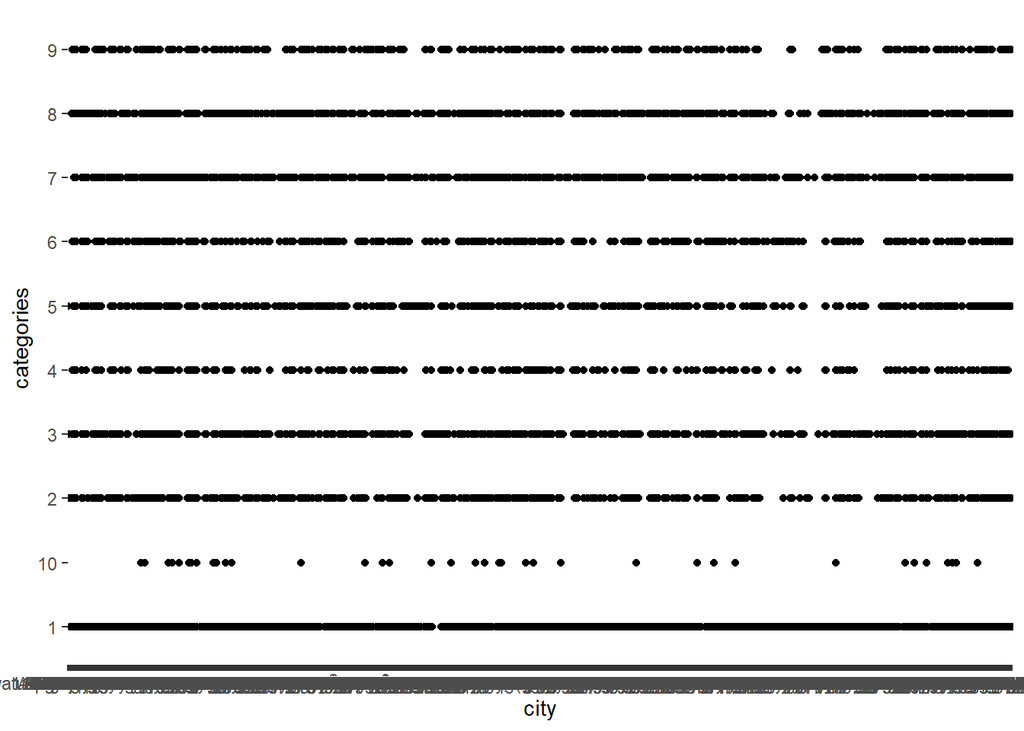

city vs categories

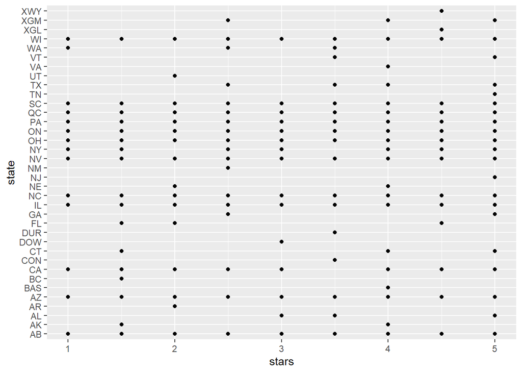

state vs star

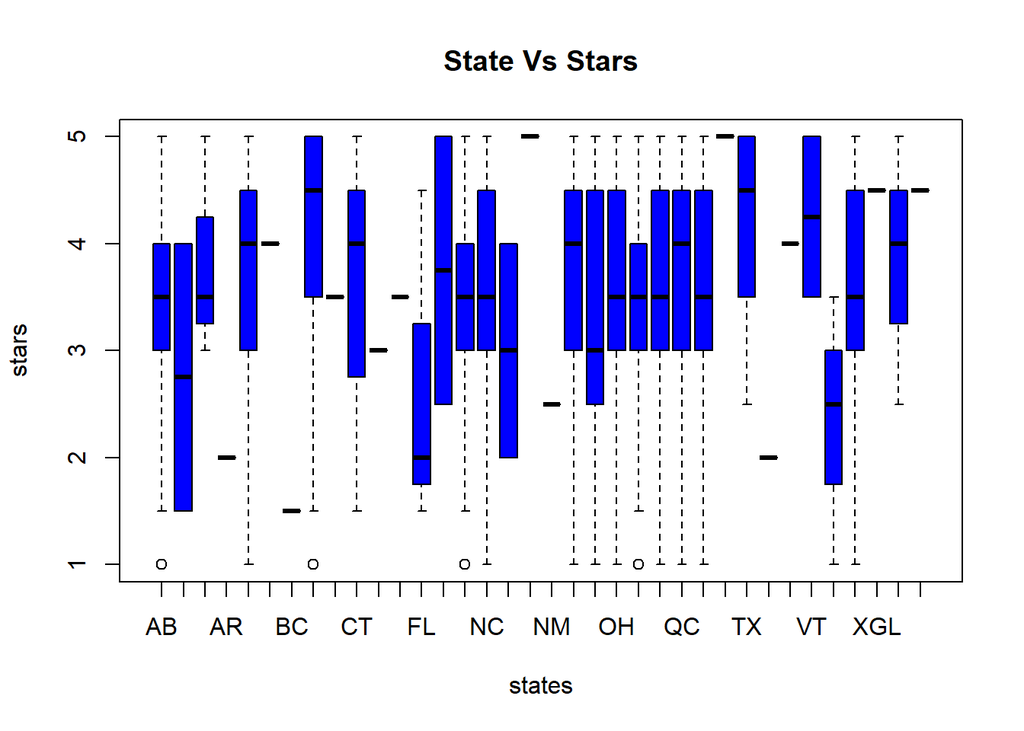

Boxplot of star vs State

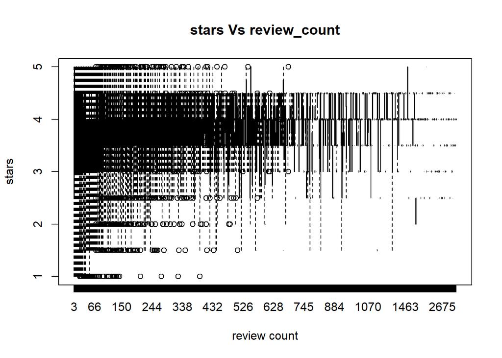

Boxplot of star vs Review count

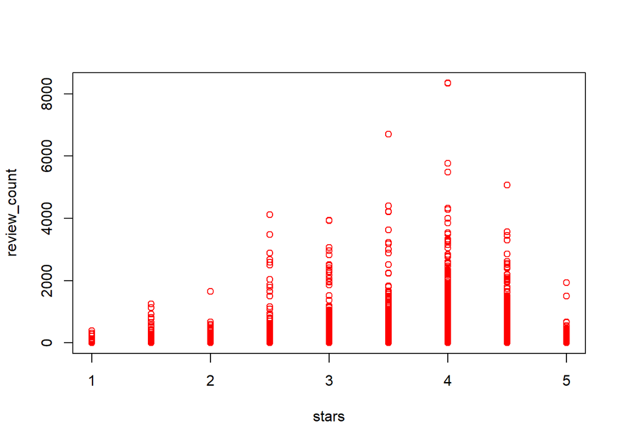

plot of star vs Review count

```
## [1] "integer"
```

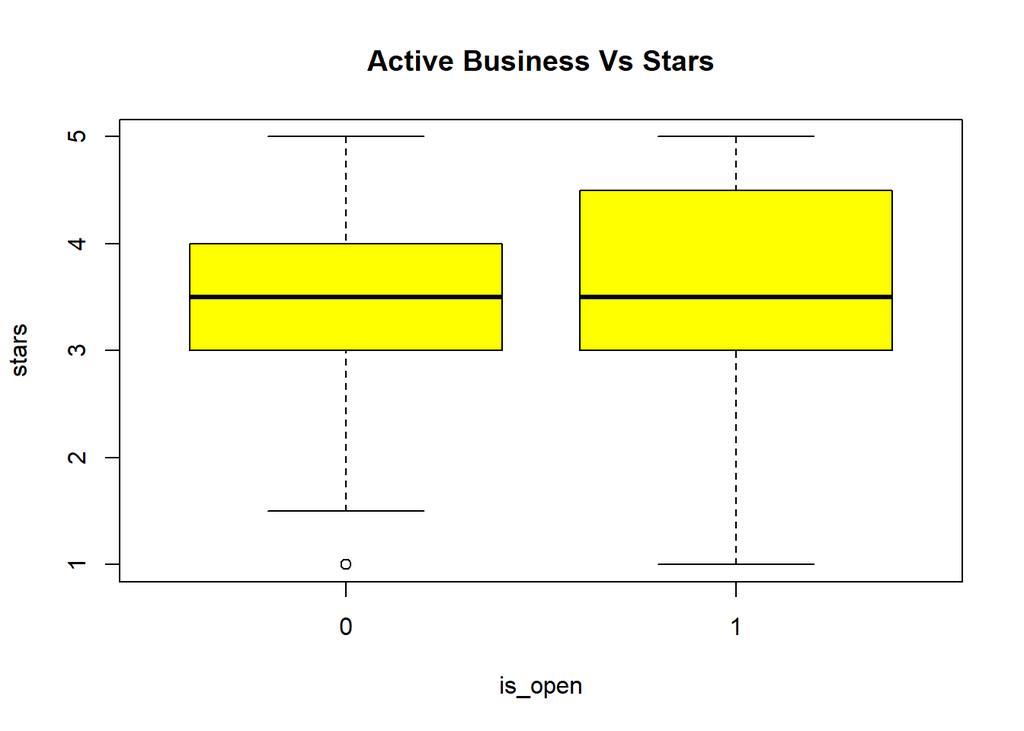

Boxplot of star vs is_open

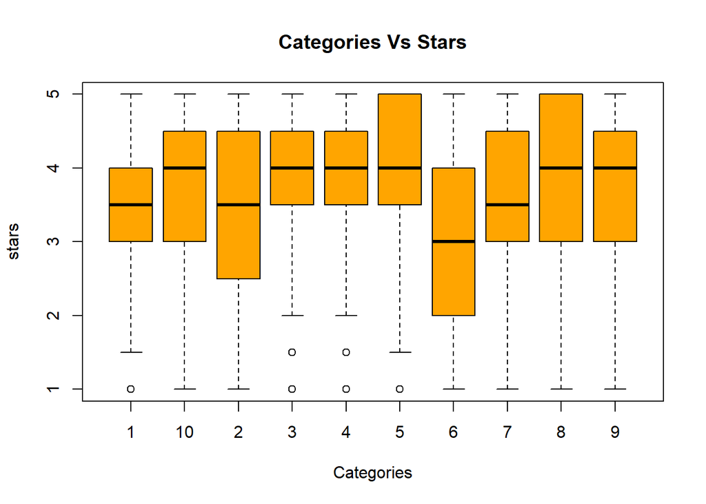

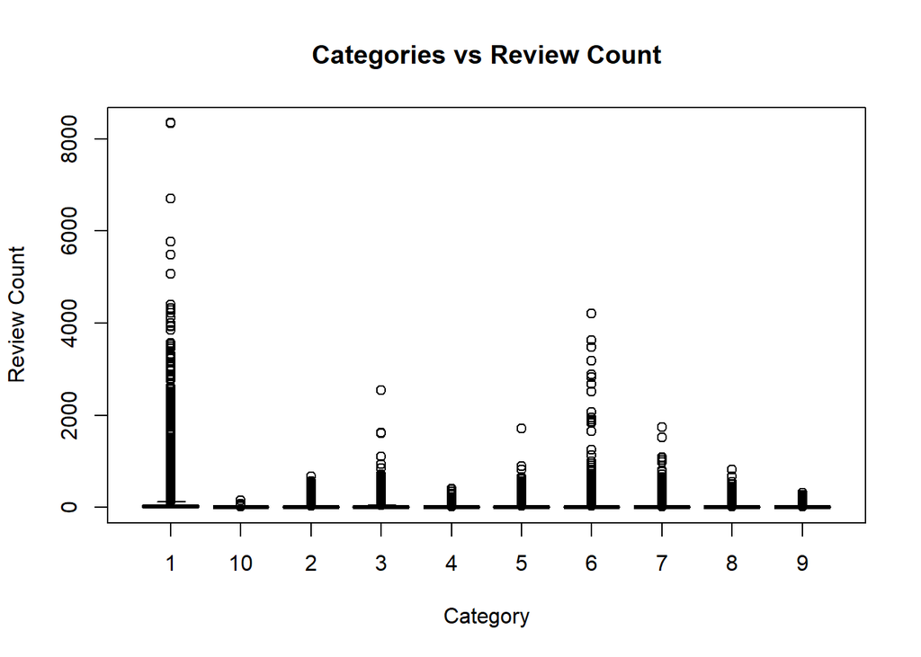

# review_count vs category Restaurants & hotel/Real state services are highly reviewd which may suggests that they have the highest market amongst these categories and people expect a lot from these businesses

# Descriptive Statistics

```
##      name               city              state
##  Length:192127      Length:192127      Length:192127
##  Class :character   Class :character   Class :character
##  Mode  :character   Mode  :character   Mode  :character
##
##
##
##
##  postal_code           latitude       longitude           stars
##  Length:192127      Min.   :33.20   Min.   :-115.49   Min.   :1.000
##  Class :character   1st Qu.:33.64   1st Qu.:-112.27   1st Qu.:3.000
##  Mode  :character   Median :36.14   Median :-111.76   Median :3.500
##                     Mean   :38.54   Mean   : -97.59   Mean   :3.589
##                     3rd Qu.:43.60   3rd Qu.: -79.98   3rd Qu.:4.500
##                     Max.   :51.30   Max.   : -72.91   Max.   :5.000
##
##   review_count     is_open      categories
##  Min.   :   3.00   0: 34063   1      :78622
##  1st Qu.:   4.00   1:158064   7      :25373
##  Median :   9.00              8      :24061
##  Mean   :  33.61              3      :20189
##  3rd Qu.:  25.00              2      :12217
##  Max.   :8348.00              9      :10287
##                               (Other):21378
```

# Descriptive stats of numerical Variables

```
## [1] NA
```

```
## [1] NA
```

```
## [1] NA
```

```
## [1] NA
```

```
## [1] NA
```

```
## [1] NA
```

```
## [1] 4.942227
```

```
## [1] 24.42561
```

```
## [1] 16.69758
```

```
## [1] 278.8091
```

```
## [1] 1.015462
```

```
## [1] 1.031163
```

```
## [1] 110.2635
```

```
## [1] 12158.03
```

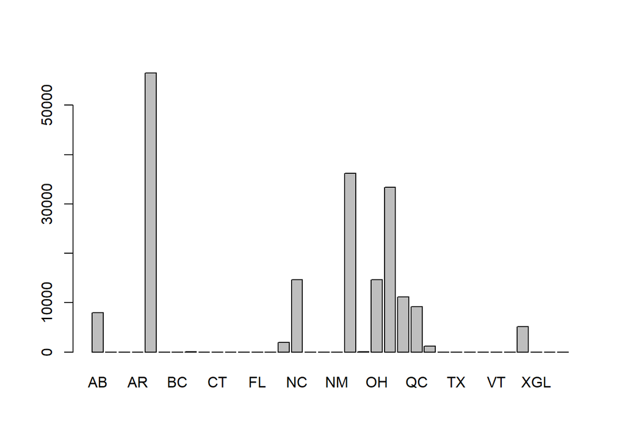

Barplot of state

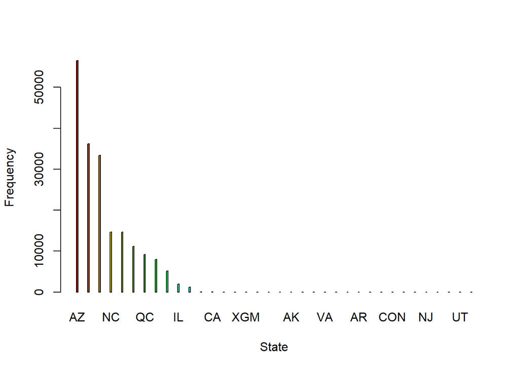

Barplot of state

# Analysis

```
##                       name      city state postal_code latitude longitude
## 82251         Mon Ami Gabi Las Vegas    NV       89109 36.11286 -115.1724
## 89207     Bacchanal Buffet Las Vegas    NV       89109 36.11611 -115.1762
## 35200         Wicked Spoon Las Vegas    NV       89109 36.10955 -115.1762
## 58853   Hash House A Go Go Las Vegas    NV       89109 36.11818 -115.1716
## 141821 Gordon Ramsay BurGR Las Vegas    NV       89109 36.11072 -115.1722
## 83951     Earl of Sandwich Las Vegas    NV       89109 36.10942 -115.1719
##        stars review_count is_open categories
## 82251    4.0         8348       1          1
## 89207    4.0         8339       1          1
## 35200    3.5         6708       1          1
## 58853    4.0         5763       1          1
## 141821   4.0         5484       0          1
## 83951    4.5         5075       1          1
```

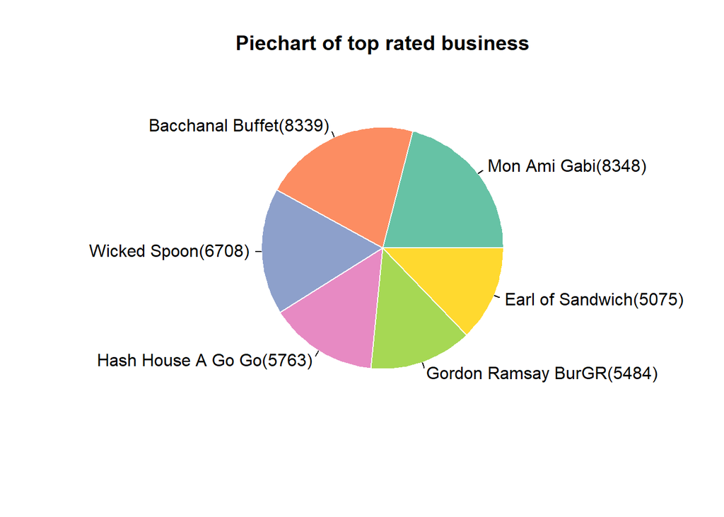

# Plotting Business Cordinates on GOOGLE Maps

#if(!requireNamespace(“devtools”)) install.packages(“devtools”) #devtools::install_github(“dkahle/ggmap”, ref = “tidyup”, force=TRUE)

```
## Google's Terms of Service: https://cloud.google.com/maps-platform/terms/.
```

[figure not shown]

locating business cordinates on Google Maps

```
## [1] "double"
```

# Normality

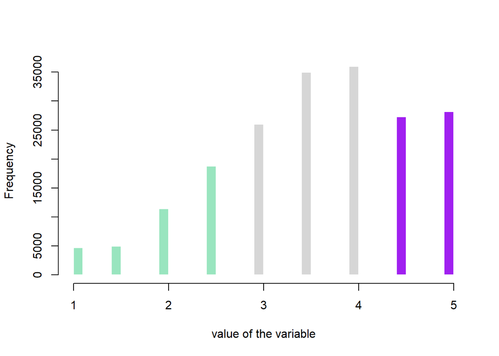

Normality check

# Statistical Tests

```
##
##  Welch Two Sample t-test
##
## data:  yfdn$stars and yfdn$review_count
## t = -119.34, df = 192159, p-value < 2.2e-16
## alternative hypothesis: true difference in means is not equal to 0
## 95 percent confidence interval:
##  -30.51586 -29.52972
## sample estimates:
## mean of x mean of y
##  3.589347 33.612137
```

```
##  [1] "coefficients"  "residuals"     "effects"       "rank"
##  [5] "fitted.values" "assign"        "qr"            "df.residual"
##  [9] "contrasts"     "xlevels"       "call"          "terms"
## [13] "model"
```

```
##                 Df    Sum Sq Mean Sq F value Pr(>F)
## categories       9 8.382e+07 9312786   794.4 <2e-16 ***
## Residuals   192117 2.252e+09   11722
## ---
## Signif. codes:  0 '***' 0.001 '**' 0.01 '*' 0.05 '.' 0.1 ' ' 1
```

#Null hypothesis : review_count are equally distributed across categories #P value is low so we will reject null hypothesis. #which means review counts are not equally distributed across categories

```
##
##  Pearson's Chi-squared test with simulated p-value (based on 2000
##  replicates)
##
## data:  yfdn$city and yfdn$categories
## X-squared = 33228, df = NA, p-value = 0.0004998
```

#Null Hypotheis : all the categories are equally distributed in each city #p value is low , so we will reject null hypothesis. #which means : all the businesses are not equally distributed across cities

```
##  [1] "coefficients"  "residuals"     "effects"       "rank"
##  [5] "fitted.values" "assign"        "qr"            "df.residual"
##  [9] "contrasts"     "xlevels"       "call"          "terms"
## [13] "model"
```

```
##                 Df Sum Sq Mean Sq F value Pr(>F)
## categories       9   7079   786.5     791 <2e-16 ***
## Residuals   192117 191035     1.0
## ---
## Signif. codes:  0 '***' 0.001 '**' 0.01 '*' 0.05 '.' 0.1 ' ' 1
```

#Null hypothesis : ratings are equally distributed across business categories #Since P value is low , we reject the null hypothesis #which means rating differs across categories